# Group 2 - Assignment 1

2024-10-22

## Task 1

Read in the CSV file:

```r
data <- read.csv("airbnb.csv", sep=",", header = TRUE)
```

Looking at the data:

```r
head(data)
```

|  | X | realSum | room_type | room_shared | room_private | person_capacity | host_is_superhost | multi | biz | cleanliness_rating | guest_satisfaction_overall | bedrooms | dist | metro_dist | attr_index | attr_index_norm | rest_index | rest_index_norm | lng | lat | weekend |
| --- | --- | --- | --- | --- | --- | --- | --- | --- | --- | --- | --- | --- | --- | --- | --- | --- | --- | --- | --- | --- | --- |
| 1 | 0 | 250.5668 | Entire home/apt | 0 | 0 | 3 | 1 | 1 | 0 | 10 | 99 | 1 | 1.732893 | 0.2126271 | 118.64683 | 8.496979 | 185.09672 | 4.424871 | 16.36500 | 48.22300 | 0 |
| 2 | 1 | 156.6043 | Entire home/apt | 0 | 0 | 3 | 0 | 0 | 0 | 10 | 97 | 1 | 4.807912 | 0.2282531 | 80.14502 | 5.739643 | 85.72760 | 2.049380 | 16.33356 | 48.17459 | 0 |
| 3 | 2 | 283.0564 | Entire home/apt | 0 | 0 | 5 | 1 | 0 | 1 | 10 | 95 | 2 | 2.811773 | 0.2441629 | 101.24811 | 7.250957 | 151.36429 | 3.618473 | 16.33600 | 48.21100 | 0 |
| 4 | 3 | 301.7554 | Entire home/apt | 0 | 0 | 4 | 1 | 0 | 1 | 10 | 94 | 2 | 3.240595 | 0.6104299 | 92.47394 | 6.622588 | 129.86383 | 3.104489 | 16.33006 | 48.20921 | 0 |
| 5 | 4 | 150.7608 | Entire home/apt | 0 | 0 | 2 | 1 | 0 | 1 | 10 | 96 | 1 | 2.241146 | 1.1195067 | 124.25677 | 8.898738 | 154.34897 | 3.689824 | 16.38867 | 48.19104 | 0 |
| 6 | 5 | 162.4477 | Private room | 0 | 1 | 2 | 1 | 1 | 0 | 10 | 99 | 1 | 4.611961 | 0.1999263 | 52.07794 | 3.729599 | 75.51554 | 1.805254 | 16.39755 | 48.24682 | 0 |

```r
str(data)
```

```
'data.frame':   3537 obs. of  21 variables:
 $ X                         : int  0 1 2 3 4 5 6 7 8 9 ...
 $ realSum                   : num  251 157 283 302 151 ...
 $ room_type                 : chr  "Entire home/apt" "Entire home/apt" "Entire home/apt" "Entire home/apt" ...
 $ room_shared               : int  0 0 0 0 0 0 0 0 0 0 ...
 $ room_private              : int  0 0 0 0 0 1 0 1 0 0 ...
 $ person_capacity           : int  3 3 5 4 2 2 3 2 4 2 ...
 $ host_is_superhost         : int  1 0 1 1 1 1 1 0 1 1 ...
 $ multi                     : int  1 0 0 0 0 1 0 0 0 1 ...
 $ biz                       : int  0 0 1 1 1 0 1 0 1 0 ...
 $ cleanliness_rating        : int  10 10 10 10 10 10 9 8 9 10 ...
 $ guest_satisfaction_overall: int  99 97 95 94 96 99 91 92 86 97 ...
 $ bedrooms                  : int  1 1 2 2 1 1 1 1 1 1 ...
 $ dist                      : num  1.73 4.81 2.81 3.24 2.24 ...
 $ metro_dist                : num  0.213 0.228 0.244 0.61 1.12 ...
 $ attr_index                : num  118.6 80.1 101.2 92.5 124.3 ...
 $ attr_index_norm           : num  8.5 5.74 7.25 6.62 8.9 ...
 $ rest_index                : num  185.1 85.7 151.4 129.9 154.3 ...
 $ rest_index_norm           : num  4.42 2.05 3.62 3.1 3.69 ...
 $ lng                       : num  16.4 16.3 16.3 16.3 16.4 ...
 $ lat                       : num  48.2 48.2 48.2 48.2 48.2 ...
 $ weekend                   : int  0 0 0 0 0 0 0 0 0 0 ...
```

There is no missing data.

```r
sum(is.na(data))
```

```
[1] 0
```

We are turning the categorial variable room_type into a factor.

```r
data$room_type <- factor(data$room_type)
```

We are eliminating the index X, because we think it is not a meaningful predictor.

```r
data <- subset(data, select = -c(1))
```

We are also eliminating attr_index and rest_index because they are not on a standardized scale like attr_index_norm or rest_index_norm. Additionally due to the fact that room_type already covers the information in room_shared and room_private, we are going to eliminate them.

```r
data <- subset(data, select = -c(room_shared, room_private, attr_index, rest_index))
```

## Task 2

Looking at the summary:

```r
summary(data)
```

```
    realSum                   room_type    person_capacity host_is_superhost     multi            biz         cleanliness_rating
 Min.   :   63.58   Entire home/apt:2747   Min.   :2.00    Min.   :0.0000    Min.   :0.000   Min.   :0.0000   Min.   : 2.000
 1st Qu.:  162.45   Private room   : 774   1st Qu.:2.00    1st Qu.:0.0000    1st Qu.:0.000   1st Qu.:0.0000   1st Qu.: 9.000
 Median :  208.49   Shared room    :  16   Median :3.00    Median :0.0000    Median :0.000   Median :0.0000   Median :10.000
 Mean   :  241.58                          Mean   :3.35    Mean   :0.2841    Mean   :0.279   Mean   :0.3398   Mean   : 9.472
 3rd Qu.:  273.47                          3rd Qu.:4.00    3rd Qu.:1.0000    3rd Qu.:1.000   3rd Qu.:1.0000   3rd Qu.:10.000
 Max.   :13664.31                          Max.   :6.00    Max.   :1.0000    Max.   :1.000   Max.   :1.0000   Max.   :10.000
 guest_satisfaction_overall    bedrooms          dist            metro_dist       attr_index_norm   rest_index_norm         lng
 Min.   : 20.00             Min.   :0.000   Min.   : 0.03981   Min.   :0.008362   Min.   :  1.388   Min.   :  0.6407   Min.   :16.21
 1st Qu.: 91.00             1st Qu.:1.000   1st Qu.: 1.88436   1st Qu.:0.242436   1st Qu.:  5.785   1st Qu.:  2.4707   1st Qu.:16.34
 Median : 96.00             Median :1.000   Median : 2.76014   Median :0.376317   Median :  7.449   Median :  3.4331   Median :16.36
 Mean   : 93.73             Mean   :1.102   Mean   : 3.13949   Mean   :0.526670   Mean   :  8.762   Mean   :  4.2396   Mean   :16.36
 3rd Qu.: 99.00             3rd Qu.:1.000   3rd Qu.: 3.93666   3rd Qu.:0.621229   3rd Qu.:  9.865   3rd Qu.:  5.0872   3rd Qu.:16.38
 Max.   :100.00             Max.   :4.000   Max.   :13.33967   Max.   :5.238383   Max.   :100.000   Max.   :100.0000   Max.   :16.55
      lat           weekend
 Min.   :48.13   Min.   :0.0000
 1st Qu.:48.19   1st Qu.:0.0000
 Median :48.20   Median :1.0000
 Mean   :48.20   Mean   :0.5086
 3rd Qu.:48.22   3rd Qu.:1.0000
 Max.   :48.29   Max.   :1.0000
```

Looking at the structure:

```r
str(data)
```

```
'data.frame':   3537 obs. of  16 variables:
 $ realSum                   : num  251 157 283 302 151 ...
 $ room_type                 : Factor w/ 3 levels "Entire home/apt",..: 1 1 1 1 1 2 1 2 1 1 ...
 $ person_capacity           : int  3 3 5 4 2 2 3 2 4 2 ...
 $ host_is_superhost         : int  1 0 1 1 1 1 1 0 1 1 ...
 $ multi                     : int  1 0 0 0 0 1 0 0 0 1 ...
 $ biz                       : int  0 0 1 1 1 0 1 0 1 0 ...
 $ cleanliness_rating        : int  10 10 10 10 10 10 9 8 9 10 ...
 $ guest_satisfaction_overall: int  99 97 95 94 96 99 91 92 86 97 ...
 $ bedrooms                  : int  1 1 2 2 1 1 1 1 1 1 ...
 $ dist                      : num  1.73 4.81 2.81 3.24 2.24 ...
 $ metro_dist                : num  0.213 0.228 0.244 0.61 1.12 ...
 $ attr_index_norm           : num  8.5 5.74 7.25 6.62 8.9 ...
 $ rest_index_norm           : num  4.42 2.05 3.62 3.1 3.69 ...
 $ lng                       : num  16.4 16.3 16.3 16.3 16.4 ...
 $ lat                       : num  48.2 48.2 48.2 48.2 48.2 ...
 $ weekend                   : int  0 0 0 0 0 0 0 0 0 0 ...
```

Looking at the correlation (only numeric values) these variables seem to be realted to realSum:

person_capacity, bedrooms, dist, attr_index_norm, rest_index_norm

```r
numeric_columns <- sapply(data, is.numeric)
numeric_data <- data[, numeric_columns]
cor(data[, 1], numeric_data)
```

```
     realSum person_capacity host_is_superhost       multi        biz cleanliness_rating guest_satisfaction_overall   bedrooms       dist
[1,]       1       0.1037146      -0.008542734 -0.03569898 0.04852438       -0.003742478                -0.00486432 0.08009713 -0.0828169
      metro_dist attr_index_norm rest_index_norm        lng        lat     weekend
[1,] -0.04171074      0.07086106       0.0702497 0.01518032 0.02004164 0.002960012
```

Plotting data: We use a logarithmic scale for the Y axis, as there are outliers in the dataset that would otherwise affect the graph negatively.

y = realSum, x = person_capacity

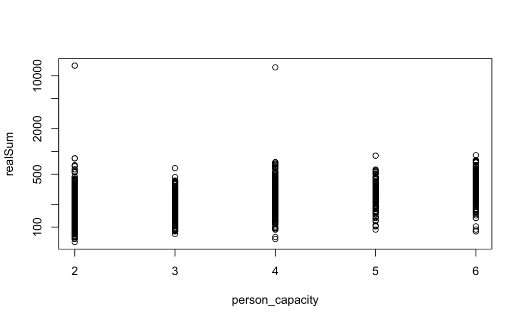

```r
plot(realSum ~ person_capacity, data = data, log = "y")
```

y = realSum, x = bedrooms

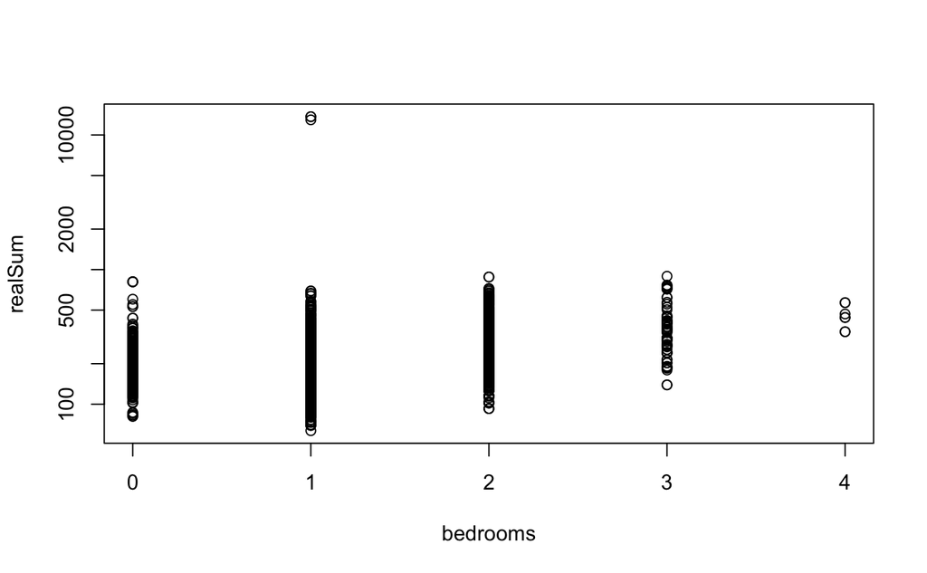

```r
plot(realSum ~ bedrooms, data = data, log = "y")
```

y = realSum, x = dist

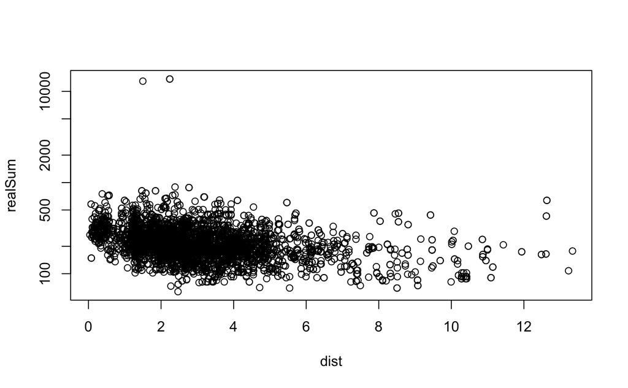

```r
plot(realSum ~ dist, data = data, log = "y")
```

y = realSum, x = metro_dist

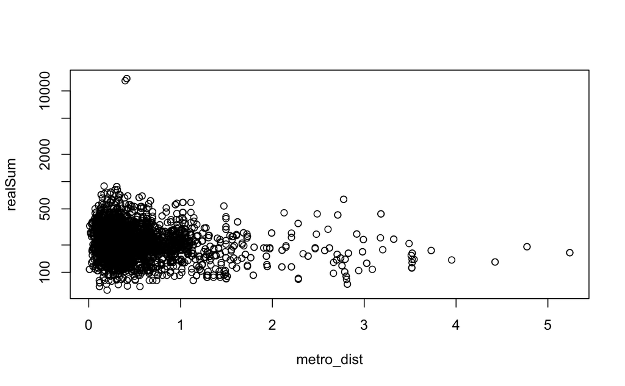

```r
plot(realSum ~ metro_dist, data = data, log = "y")
```

y = realSum, x = attr_index_norm

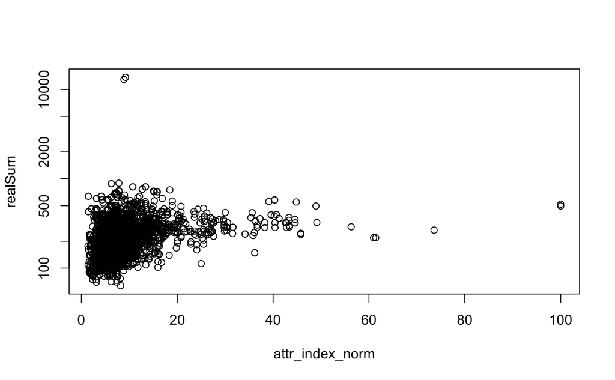

```r
plot(realSum ~ attr_index_norm, data = data, log = "y")
```

y = realSum, x = rest_index_norm

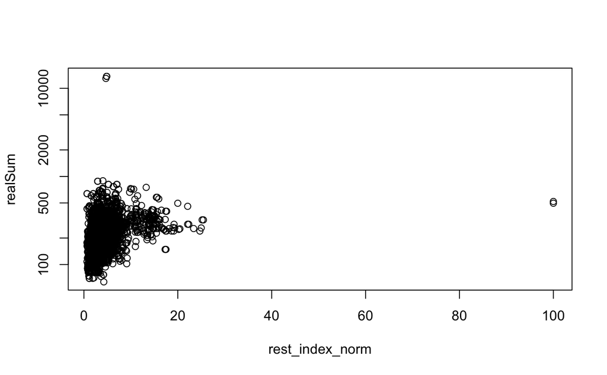

```r
plot(realSum ~ rest_index_norm, data = data, log = "y")
```

## Task 3

Fitting a linear regression model by using all variables. Significant impact on price: person_capacity, bedrooms and dist

```r
fitAll <- lm(realSum ~ ., data = data)
summary(fitAll)
```

```
Call:
lm(formula = realSum ~ ., data = data)

Residuals:
    Min      1Q  Median      3Q     Max
 -197.7   -61.9   -25.3    18.8 13462.3

Coefficients:
                             Estimate Std. Error t value Pr(>|t|)
(Intercept)                -11578.605  16299.795  -0.710  0.47753
room_typePrivate room         -24.307     18.016  -1.349  0.17736
room_typeShared room          -97.322     99.570  -0.977  0.32843
person_capacity                19.678      6.798   2.894  0.00382 **
host_is_superhost             -13.500     15.491  -0.871  0.38354
multi                         -19.771     16.700  -1.184  0.23654
biz                            21.537     16.519   1.304  0.19241
cleanliness_rating             -5.512     10.116  -0.545  0.58585
guest_satisfaction_overall      1.006      1.228   0.819  0.41289
bedrooms                       34.518     13.204   2.614  0.00898 **
dist                          -12.301      5.150  -2.388  0.01698 *
metro_dist                      2.827     16.129   0.175  0.86088
attr_index_norm                 1.771      2.310   0.766  0.44347
rest_index_norm                 1.405      3.839   0.366  0.71430
lng                            78.291    188.287   0.416  0.67758
lat                           216.086    346.659   0.623  0.53310
weekend                         0.861     13.268   0.065  0.94826
---
Signif. codes:  0 ‘***’ 0.001 ‘**’ 0.01 ‘*’ 0.05 ‘.’ 0.1 ‘ ’ 1

Residual standard error: 394.1 on 3520 degrees of freedom
Multiple R-squared:  0.02293,   Adjusted R-squared:  0.01849
F-statistic: 5.163 on 16 and 3520 DF,  p-value: 7.829e-11
```

## Task 4

Performing a stepwise approach to filter out unnecessary variables.

positive impact: person_capacity, bedrooms, attr_index_norm

negative impact: multi, dist

All coefficient signs of the variables were expected intuitively, the coefficient of the variable “multi” was not expected, one possible explanation could be that the hosts with more apartments could have economies of scale effects.

The coefficient of “dist” is negative because the greater the distance to the city center the cheaper an airbnb should be.

The variable “room_type” was omitted in the stepwise regression model, because the AIC was lower when it was not considered in the model. That means, that “room_type” has not a big impact on the price.

```r
fitStepwise = step(fitAll, direction = "backward")
```

```
Start:  AIC=42294.62
realSum ~ room_type + person_capacity + host_is_superhost + multi +
    biz + cleanliness_rating + guest_satisfaction_overall + bedrooms +
    dist + metro_dist + attr_index_norm + rest_index_norm + lng +
    lat + weekend

                             Df Sum of Sq       RSS   AIC
- weekend                     1       654 546579017 42293
- metro_dist                  1      4770 546583134 42293
- rest_index_norm             1     20814 546599177 42293
- lng                         1     26847 546605210 42293
- cleanliness_rating          1     46107 546624471 42293
- lat                         1     60333 546638697 42293
- attr_index_norm             1     91213 546669576 42293
- room_type                   2    410251 546988614 42293
- guest_satisfaction_overall  1    104134 546682497 42293
- host_is_superhost           1    117935 546696298 42293
- multi                       1    217638 546796002 42294
- biz                         1    263934 546842298 42294
<none>                                    546578364 42295
- dist                        1    885687 547464050 42298
- bedrooms                    1   1061245 547639609 42299
- person_capacity             1   1300874 547879238 42301

Step:  AIC=42292.63
realSum ~ room_type + person_capacity + host_is_superhost + multi +
    biz + cleanliness_rating + guest_satisfaction_overall + bedrooms +
    dist + metro_dist + attr_index_norm + rest_index_norm + lng +
    lat

                             Df Sum of Sq       RSS   AIC
- metro_dist                  1      4709 546583726 42291
- rest_index_norm             1     20918 546599935 42291
- lng                         1     27044 546606061 42291
- cleanliness_rating          1     46014 546625032 42291
- lat                         1     60222 546639239 42291
- attr_index_norm             1     90984 546670001 42291
- room_type                   2    410035 546989052 42291
- guest_satisfaction_overall  1    104052 546683070 42291
- host_is_superhost           1    118340 546697358 42291
```

[output cut: 137 more lines]

```
- attr_index_norm  1    499098 547848739 42281
- bedrooms         1   1017852 548367493 42284
- dist             1   1446106 548795747 42287
- person_capacity  1   2080129 549429770 42291

Step:  AIC=42279.29
realSum ~ person_capacity + multi + bedrooms + dist + attr_index_norm

                  Df Sum of Sq       RSS   AIC
<none>                         547609762 42279
- attr_index_norm  1    500337 548110099 42281
- multi            1    700608 548310370 42282
- bedrooms         1    882744 548492506 42283
- dist             1   1479973 549089735 42287
- person_capacity  1   2565968 550175730 42294
```

```r
summary(fitStepwise)
```

```
Call:
lm(formula = realSum ~ person_capacity + multi + bedrooms + dist +
    attr_index_norm, data = data)

Residuals:
    Min      1Q  Median      3Q     Max
 -218.3   -62.4   -25.7    21.8 13437.3

Coefficients:
                Estimate Std. Error t value Pr(>|t|)
(Intercept)      155.098     29.462   5.264 1.49e-07 ***
person_capacity   24.472      6.016   4.068 4.85e-05 ***
multi            -31.423     14.784  -2.125  0.03362 *
bedrooms          30.597     12.825   2.386  0.01710 *
dist             -13.096      4.239  -3.089  0.00202 **
attr_index_norm    2.357      1.312   1.796  0.07255 .
---
Signif. codes:  0 ‘***’ 0.001 ‘**’ 0.01 ‘*’ 0.05 ‘.’ 0.1 ‘ ’ 1

Residual standard error: 393.8 on 3531 degrees of freedom
Multiple R-squared:  0.02109,   Adjusted R-squared:  0.0197
F-statistic: 15.21 on 5 and 3531 DF,  p-value: 8.127e-15
```

## Task 5

As expected, the stepwise model had the lower AIC.

```r
AIC(fitAll)
```

```
[1] 52334.19
```

```r
AIC(fitStepwise)
```

```
[1] 52318.86
```

## Task 6

Splitting the sample into 80% train vs 20% test sample.

```r
total_rows <- nrow(data)
eighty_percent <- floor(0.8 * total_rows)
set.seed(123)

for_training <- sample(1:total_rows, eighty_percent, replace = FALSE)

train_data <- data[for_training,]
test_data <- data[-for_training,]
```

Fitting the full model to the training data:

```r
model_full <- lm(realSum ~ ., data = train_data)
summary(model_full)
```

```
Call:
lm(formula = realSum ~ ., data = train_data)

Residuals:
    Min      1Q  Median      3Q     Max
 -202.3   -67.0   -28.4    18.8 13445.2

Coefficients:
                             Estimate Std. Error t value Pr(>|t|)
(Intercept)                -11124.972  20296.851  -0.548   0.5837
room_typePrivate room         -16.297     22.266  -0.732   0.4643
room_typeShared room          -86.156    123.170  -0.699   0.4843
person_capacity                19.318      8.488   2.276   0.0229 *
host_is_superhost             -16.170     19.366  -0.835   0.4038
multi                         -24.938     20.867  -1.195   0.2322
biz                            20.167     20.570   0.980   0.3270
cleanliness_rating             -7.714     12.580  -0.613   0.5398
guest_satisfaction_overall      1.003      1.513   0.663   0.5076
bedrooms                       34.521     16.442   2.100   0.0359 *
dist                          -13.930      6.512  -2.139   0.0325 *
metro_dist                      7.823     20.164   0.388   0.6981
attr_index_norm                 1.685      3.128   0.539   0.5900
rest_index_norm                 2.085      5.516   0.378   0.7055
lng                            52.241    232.526   0.225   0.8223
lat                           216.108    431.404   0.501   0.6165
weekend                        -1.308     16.550  -0.079   0.9370
---
Signif. codes:  0 ‘***’ 0.001 ‘**’ 0.01 ‘*’ 0.05 ‘.’ 0.1 ‘ ’ 1

Residual standard error: 439 on 2812 degrees of freedom
Multiple R-squared:  0.01854,   Adjusted R-squared:  0.01295
F-statistic: 3.319 on 16 and 2812 DF,  p-value: 8.296e-06
```

Creating a stepwise regression model on the training data.

The variables are ommited:

```r
model_step <- step(model_full, direction = "backward")
```

```
Start:  AIC=34442.72
realSum ~ room_type + person_capacity + host_is_superhost + multi +
    biz + cleanliness_rating + guest_satisfaction_overall + bedrooms +
    dist + metro_dist + attr_index_norm + rest_index_norm + lng +
    lat + weekend

                             Df Sum of Sq       RSS   AIC
- room_type                   2    187252 542057132 34440
- weekend                     1      1203 541871083 34441
- lng                         1      9727 541879606 34441
- rest_index_norm             1     27518 541897397 34441
- metro_dist                  1     29007 541898887 34441
- lat                         1     48356 541918236 34441
- attr_index_norm             1     55955 541925835 34441
- cleanliness_rating          1     72464 541942343 34441
- guest_satisfaction_overall  1     84601 541954480 34441
- host_is_superhost           1    134333 542004213 34441
- biz                         1    185219 542055098 34442
- multi                       1    275204 542145083 34442
<none>                                    541869880 34443
- bedrooms                    1    849446 542719325 34445
- dist                        1    881781 542751661 34445
- person_capacity             1    998227 542868107 34446

Step:  AIC=34439.7
realSum ~ person_capacity + host_is_superhost + multi + biz +
    cleanliness_rating + guest_satisfaction_overall + bedrooms +
    dist + metro_dist + attr_index_norm + rest_index_norm + lng +
    lat + weekend

                             Df Sum of Sq       RSS   AIC
- weekend                     1      1753 542058885 34438
- lng                         1      9814 542066946 34438
- rest_index_norm             1     30322 542087454 34438
- metro_dist                  1     40775 542097907 34438
- attr_index_norm             1     51230 542108362 34438
- lat                         1     51547 542108679 34438
- cleanliness_rating          1     52416 542109548 34438
- guest_satisfaction_overall  1     83996 542141128 34438
- host_is_superhost           1    131905 542189037 34438
```

[output cut: 139 more lines]

```
- attr_index_norm  1    404108 542854162 34426
- bedrooms         1    885079 543335133 34428
- dist             1   1279202 543729256 34430
- person_capacity  1   1400134 543850188 34431

Step:  AIC=34424.63
realSum ~ person_capacity + multi + bedrooms + dist + attr_index_norm

                  Df Sum of Sq       RSS   AIC
<none>                         542618905 34425
- attr_index_norm  1    407749 543026654 34425
- multi            1    722581 543341485 34426
- bedrooms         1    780433 543399338 34427
- dist             1   1298398 543917303 34429
- person_capacity  1   1747491 544366396 34432
```

```r
summary(model_step)
```

```
Call:
lm(formula = realSum ~ person_capacity + multi + bedrooms + dist +
    attr_index_norm, data = train_data)

Residuals:
    Min      1Q  Median      3Q     Max
 -219.2   -66.7   -28.1    19.2 13429.1

Coefficients:
                Estimate Std. Error t value Pr(>|t|)
(Intercept)      165.805     37.574   4.413 1.06e-05 ***
person_capacity   22.625      7.504   3.015  0.00259 **
multi            -35.817     18.473  -1.939  0.05262 .
bedrooms          32.092     15.927   2.015  0.04400 *
dist             -13.885      5.343  -2.599  0.00940 **
attr_index_norm    2.515      1.727   1.456  0.14537
---
Signif. codes:  0 ‘***’ 0.001 ‘**’ 0.01 ‘*’ 0.05 ‘.’ 0.1 ‘ ’ 1

Residual standard error: 438.4 on 2823 degrees of freedom
Multiple R-squared:  0.01718,   Adjusted R-squared:  0.01544
F-statistic:  9.87 on 5 and 2823 DF,  p-value: 2.274e-09
```

Making predictons on the test data with both models:

```r
pred_test_model_full = predict(model_full, newdata = test_data)
pred_test_model_step = predict(model_step, newdata = test_data)

pred_train_model_full <- predict(model_full, newdata = train_data)
pred_train_model_step <- predict(model_step, newdata = train_data)
```

Calculate the training and the test MSE:

```r
mse_train_model_full <- mean((train_data$realSum - pred_train_model_full)^2)
mse_train_model_step <- mean((train_data$realSum - pred_train_model_step)^2)

mse_test_model_full <- mean((test_data$realSum - pred_test_model_full)^2)
mse_test_model_step <- mean((test_data$realSum - pred_test_model_step)^2)
```

Displaying the training MSE:

Training MSE: When it comes to the training MSE, the full model should be lower, than the stepwise model. The full model performs better.

```r
mse_train_model_full
```

```
[1] 191541.1
```

```r
mse_train_model_step
```

```
[1] 191805.9
```

Displaying the test MSE:

Test MSE: When it comes to the test MSE, the the stepwise model should be lower, than the full model. The full model performs better.

For the final model someone should choose the lowest test MSE. In this case it would be the full test model.

```r
mse_test_model_full
```

```
[1] 6914.267
```

```r
mse_test_model_step
```

```
[1] 7185.729
```